# 2015-Zanconato (ChIp-seq): Fig 1c

[Krittiyabhorn (Namthip) Kongtanawanich](https://kuchikinamthip.github.io/)

2025-01-15

These are the figures we will reproduce in this section.

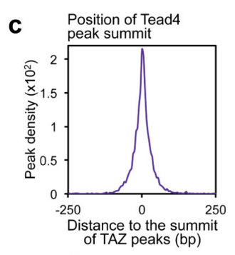

Figure 1c

```r
R.version.string # show R version
```

```
## [1] "R version 4.4.1 (2024-06-14)"
```

Loading the library.

```r
library(GenomicRanges)
library(rtracklayer) # for reading in bed file
library(here) # for file path
```

Importing the peak files, which are the output from `macs3` where `narrowPeak` mode was used for ChIP-seq of transcription factors.

```r
TAZ_peaks<- import(here("data/HPC/bowtie2/macs3/TAZ_REP1_peaks.narrowPeak"))
YAP_peaks<- import(here("data/HPC/bowtie2/macs3/YAP_REP1_peaks.narrowPeak"))
```

## Figure 1c: Position of TEAD4 peak summits relative to the summits of the overlapping YAP/TAZ peaks

Figure described “position of TEAD4 peak summits relative to the summits of the overlapping YAP/TAZ peaks, in a 500 bp window surrounding the summit of YAP/TAZ peaks.”

TAZ peaks coordinates represent common peaks between YAP and TAZ peaks (YAP/TAZ peaks) (These were used when comparing YAP/TAZ peaks with other ChIP-seq data).  
So, what we need as input data for each axis are  
1. x-axis: TAZ peak file  
2. y-axis: TEAD4 peak file which peak density on TAZ will further calculate.

We will do it in a way that makes us understand the principle behind this plot; after understanding the principle, we can use the R package like [`ChIPseeker`](http://bioconductor.riken.jp/packages/3.4/bioc/vignettes/ChIPseeker/inst/doc/ChIPseeker.html) to do it as well.

In this case, based on the distance plot centered at 0, we will use output from `macs3`(peak calling tool) the `_summit.bed` file, which identifies the single base with the highest signal within each peak. This is better than the `narrowPeak.bed` file, which provides all positions within a peak where the transcription factor binds.

Step 1: Importing `_summit.bed` file.

```r
TAZ_summit <- import(here("data/HPC/bowtie2/macs3/TAZ_REP1_summits.bed"))
TAZ_summit # All peaks from TAZ = 9509
```

```
## GRanges object with 9509 ranges and 2 metadata columns:
##          seqnames    ranges strand |               name     score
##             <Rle> <IRanges>  <Rle> |        <character> <numeric>
##      [1]     chr1     10059      * |    TAZ_REP1_peak_1   9.04597
##      [2]     chr1     10194      * |    TAZ_REP1_peak_2  10.16240
##      [3]     chr1    180791      * |    TAZ_REP1_peak_3   4.07683
##      [4]     chr1   1024814      * |    TAZ_REP1_peak_4  50.71850
##      [5]     chr1   1265028      * |    TAZ_REP1_peak_5  16.16140
##      ...      ...       ...    ... .                ...       ...
##   [9505]     chrX 154733329      * | TAZ_REP1_peak_9505   2.32820
##   [9506]     chrX 154735831      * | TAZ_REP1_peak_9506   3.91207
##   [9507]     chrX 154797199      * | TAZ_REP1_peak_9507   3.91207
##   [9508]     chrX 155888407      * | TAZ_REP1_peak_9508  10.80710
##   [9509]     chrX 156030545      * | TAZ_REP1_peak_9509  31.87160
##   -------
##   seqinfo: 26 sequences from an unspecified genome; no seqlengths
```

```r
# Find overlapping TAZ and YAP
TAZ_overlap_YAP_peaks <- subsetByOverlaps(TAZ_peaks, YAP_peaks)
TAZ_summit1 <- TAZ_summit[TAZ_summit$name %in% TAZ_overlap_YAP_peaks$name]
TAZ_summit1
```

```
## GRanges object with 6909 ranges and 2 metadata columns:
##          seqnames    ranges strand |               name     score
##             <Rle> <IRanges>  <Rle> |        <character> <numeric>
##      [1]     chr1   1024814      * |    TAZ_REP1_peak_4   50.7185
##      [2]     chr1   1265028      * |    TAZ_REP1_peak_5   16.1614
##      [3]     chr1   1265429      * |    TAZ_REP1_peak_6   12.7515
##      [4]     chr1   1360766      * |    TAZ_REP1_peak_7   27.3256
##      [5]     chr1   2061535      * |   TAZ_REP1_peak_11   31.4823
##      ...      ...       ...    ... .                ...       ...
##   [6905]     chrX 154369087      * | TAZ_REP1_peak_9502   8.09378
##   [6906]     chrX 154596742      * | TAZ_REP1_peak_9503  10.59780
##   [6907]     chrX 154600772      * | TAZ_REP1_peak_9504  11.66930
##   [6908]     chrX 154733329      * | TAZ_REP1_peak_9505   2.32820
##   [6909]     chrX 155888407      * | TAZ_REP1_peak_9508  10.80710
##   -------
##   seqinfo: 26 sequences from an unspecified genome; no seqlengths
```

CAUSION!  
Take a look at `TAZ_summit$name` and `TAZ_overlap_YAP_peaks$name`; the names have to be the same to perform `TAZ_summit$name %in% TAZ_overlap_YAP_peaks$name`.

```r
head(TAZ_summit$name)
```

```
## [1] "TAZ_REP1_peak_1" "TAZ_REP1_peak_2" "TAZ_REP1_peak_3" "TAZ_REP1_peak_4"
## [5] "TAZ_REP1_peak_5" "TAZ_REP1_peak_6"
```

```r
head(TAZ_overlap_YAP_peaks$name)
```

```
## [1] "TAZ_REP1_peak_4"  "TAZ_REP1_peak_5"  "TAZ_REP1_peak_6"  "TAZ_REP1_peak_7"
## [5] "TAZ_REP1_peak_11" "TAZ_REP1_peak_12"
```

So this code will resulted in a error `TAZ_summit$name %in% YAP_overlap_TAZ_peaks$name`.

Next, importing `TEAD4_summit.bed` file.

```r
TEAD4_summit <- import(here("data/HPC/bowtie2/macs3/TEAD4_REP1_summits.bed"))
TEAD4_summit # All peak from TEAD4 = 10668
```

```
## GRanges object with 10668 ranges and 2 metadata columns:
##           seqnames    ranges strand |                  name     score
##              <Rle> <IRanges>  <Rle> |           <character> <numeric>
##       [1]     chr1   1024820      * |     TEAD4_REP1_peak_1  35.34760
##       [2]     chr1   1265049      * |     TEAD4_REP1_peak_2  43.23410
##       [3]     chr1   1360768      * |     TEAD4_REP1_peak_3  59.26370
##       [4]     chr1   1659305      * |     TEAD4_REP1_peak_4   6.84313
##       [5]     chr1   2061491      * |     TEAD4_REP1_peak_5  30.11540
##       ...      ...       ...    ... .                   ...       ...
##   [10664]     chrX 154733086      * | TEAD4_REP1_peak_10664   8.44084
##   [10665]     chrX 154735953      * | TEAD4_REP1_peak_10665  11.36370
##   [10666]     chrX 154967763      * | TEAD4_REP1_peak_10666   7.61277
##   [10667]     chrX 155057492      * | TEAD4_REP1_peak_10667   4.40812
##   [10668]     chrX 155888349      * | TEAD4_REP1_peak_10668   9.29092
##   -------
##   seqinfo: 25 sequences from an unspecified genome; no seqlengths
```

Since the x-axis is a range of DNA distance around the TAZ peak, we have to expand TAZ first.

Expand the TAZ summit to a 500 bp window by fixing the center (remember?, we have information from `_summit.bed` as single base) –> see the details of [expand by fixing center](https://jianhong.github.io/workshop2020/articles/ChIPpeakAnno.html).

```r
TAZ_500bp_window <- resize(TAZ_summit, width = 500, fix="center")

# find overlapping between TEAD4 and TAZ _summit.bed file
hits <- findOverlaps(TEAD4_summit, TAZ_500bp_window)
# NOTE: TEAD4_summit = query, TAZ = subject --> this just to see the results in hits

# a hits object with the indices of the overlapping query and subject
hits
```

```
## Hits object with 6391 hits and 0 metadata columns:
##          queryHits subjectHits
##          <integer>   <integer>
##      [1]         1           4
##      [2]         2           5
##      [3]         3           7
##      [4]         5          11
##      [5]         6          12
##      ...       ...         ...
##   [6387]     10661        9503
##   [6388]     10662        9504
##   [6389]     10664        9505
##   [6390]     10665        9506
##   [6391]     10668        9508
##   -------
##   queryLength: 10668 / subjectLength: 9509
```

The hits object indicates that TEAD4 peak(query) #1 overlaps with TAZ peak (subject) #4, and TEAD4 peak #2 overlaps with TAZ peak #5, so on and so forth.

Next, we will find the distance between each match.

```r
summit_distance <- distance(TEAD4_summit[queryHits(hits)], TAZ_summit[subjectHits(hits)])

# Here is the distance of each match.
table(summit_distance)
```

```
## summit_distance
##   0   1   2   3   4   5   6   7   8   9  10  11  12  13  14  15  16  17  18  19
## 234 135 118 135 122 120 128 121 114 134 124 106 114 114 111 109 104 109  96 111
##  20  21  22  23  24  25  26  27  28  29  30  31  32  33  34  35  36  37  38  39
##  90  92  88  96  92  86  75  84  72  60  84  68  78  71  62  74  61  66  63  61
##  40  41  42  43  44  45  46  47  48  49  50  51  52  53  54  55  56  57  58  59
##  56  50  47  73  51  66  57  48  47  42  44  48  39  49  46  48  40  35  47  39
##  60  61  62  63  64  65  66  67  68  69  70  71  72  73  74  75  76  77  78  79
##  40  27  29  37  33  33  36  29  32  29  30  33  21  34  25  22  26  18  26  24
##  80  81  82  83  84  85  86  87  88  89  90  91  92  93  94  95  96  97  98  99
##  11  15  13  20  18  35  26  18  20  18  11  13   8  13  20  18   8  20  14  18
## 100 101 102 103 104 105 106 107 108 109 110 111 112 113 114 115 116 117 118 119
##  14   7  12  16  11  16   8   7   9  10  11  10  12   8  10   3  12   5   5   8
## 120 121 122 123 124 125 126 127 128 129 130 131 132 133 134 135 136 137 138 139
##  11   6   9   6   8  10   6   7   4   4   7   9   8   2   8   5   5   7   2   5
## 140 141 142 143 144 145 146 147 148 149 150 151 152 153 154 155 156 157 158 159
##   2   2   4   5   7   6   6   1   3   5   3   6   3   4   2   3   2   2   1   1
## 160 161 163 164 165 166 167 168 169 170 171 173 175 176 177 179 180 182 183 184
##   2   2   1   1   5   3   2   4   5   2   4   1   3   1   2   2   4   2   2   1
## 185 186 187 191 192 193 194 195 197 199 200 201 202 203 204 205 209 211 212 213
##   1   4   4   1   4   1   1   2   4   3   2   4   1   2   1   1   2   2   1   3
## 214 216 217 218 219 220 222 223 224 225 227 228 230 232 233 234 235 236 240 241
##   1   1   2   1   1   1   3   1   1   1   2   1   1   1   2   2   1   1   2   2
## 242 245 246
##   2   1   1
```

```r
length((summit_distance)) # All match points between TEAD4 and TAZ peaks
```

```
## [1] 6391
```

```r
TEAD4_summit[queryHits(hits)][summit_distance ==0]
```

```
## GRanges object with 234 ranges and 2 metadata columns:
##         seqnames    ranges strand |                  name     score
##            <Rle> <IRanges>  <Rle> |           <character> <numeric>
##     [1]     chr1   8212094      * |    TEAD4_REP1_peak_27   12.4059
##     [2]     chr1  24713384      * |   TEAD4_REP1_peak_117   38.7188
##     [3]     chr1  33099450      * |   TEAD4_REP1_peak_172   45.1086
##     [4]     chr1  43207014      * |   TEAD4_REP1_peak_214  104.8170
##     [5]     chr1  43822190      * |   TEAD4_REP1_peak_219   61.9982
##     ...      ...       ...    ... .                   ...       ...
##   [230]     chr9 120366813      * | TEAD4_REP1_peak_10436  47.08490
##   [231]     chr9 134544508      * | TEAD4_REP1_peak_10511  17.88210
##   [232]     chr9 136572251      * | TEAD4_REP1_peak_10515 114.31800
##   [233]     chrX  17602870      * | TEAD4_REP1_peak_10549  18.17520
##   [234]     chrX 101208245      * | TEAD4_REP1_peak_10603   9.77202
##   -------
##   seqinfo: 25 sequences from an unspecified genome; no seqlengths
```

```r
TAZ_summit[subjectHits(hits)][summit_distance ==0]
```

```
## GRanges object with 234 ranges and 2 metadata columns:
##         seqnames    ranges strand |               name     score
##            <Rle> <IRanges>  <Rle> |        <character> <numeric>
##     [1]     chr1   8212095      * |   TAZ_REP1_peak_26   9.50935
##     [2]     chr1  24713384      * |  TAZ_REP1_peak_104  14.95960
##     [3]     chr1  33099451      * |  TAZ_REP1_peak_160  50.37360
##     [4]     chr1  43207015      * |  TAZ_REP1_peak_208 103.03700
##     [5]     chr1  43822191      * |  TAZ_REP1_peak_211  24.06110
##     ...      ...       ...    ... .                ...       ...
##   [230]     chr9 120366813      * | TAZ_REP1_peak_9284  19.31370
##   [231]     chr9 134544508      * | TAZ_REP1_peak_9372  18.39740
##   [232]     chr9 136572251      * | TAZ_REP1_peak_9379 100.08700
##   [233]     chrX  17602870      * | TAZ_REP1_peak_9406   8.07704
##   [234]     chrX 101208245      * | TAZ_REP1_peak_9445   5.29685
##   -------
##   seqinfo: 26 sequences from an unspecified genome; no seqlengths
```

From figure 1c, there are positive and negative values on the x-axis.  
We now have distance values, so we will turn them into positive or negative by assuming that  
1. Negative values: when TEAD4 summit precede the TAZ summit (TEAD4…then TAZ).  
2. Positive values: when TEAD4 summit follows TAZ summit. (TAZ …then TEAD4)

```r
# Compute signed distances
signed_distance <- function(A, B) {
  # Compute unsigned distance
  dist <- distance(A, B)

  # Determine signs based on whether A precedes or follows B
  sign <- ifelse(start(A) < start(B), -1, 1)

  # Apply sign to distance
  dist * sign
}
```

Let’s make the sign to the distance.

```r
library(dplyr)
library(ggplot2)

summit_distance <- signed_distance(TEAD4_summit[queryHits(hits)],
                                  TAZ_summit[subjectHits(hits)])

distance_df<- table(summit_distance) %>%
  tibble::as_tibble()

distance_df
```

```
## # A tibble: 393 × 2
##    summit_distance     n
##    <chr>           <int>
##  1 -245                1
##  2 -242                2
##  3 -241                1
##  4 -240                1
##  5 -236                1
##  6 -234                1
##  7 -232                1
##  8 -230                1
##  9 -228                1
## 10 -227                1
## # ℹ 383 more rows
```

Making a plot!

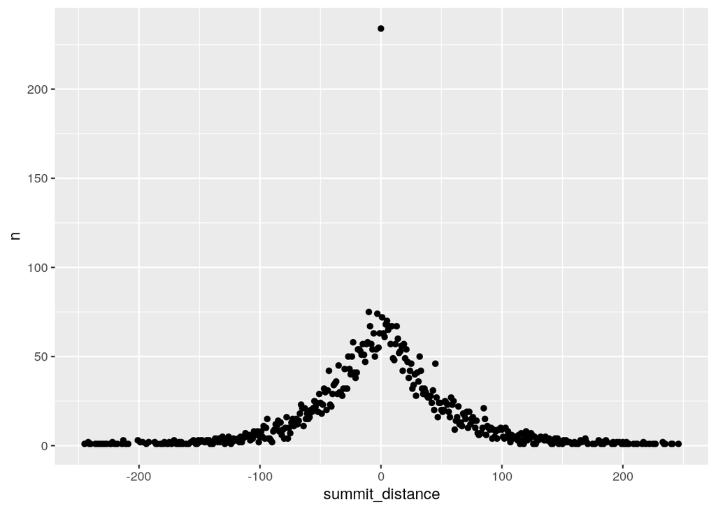

```r
distance_df %>%
  mutate(summit_distance = as.numeric(summit_distance)) %>%
  arrange(summit_distance) %>% #To arrange according to the values
  ggplot(aes(x=summit_distance, y = n)) +
  geom_point()
```

We now see how each value makes a peak in the middle; then we change to a line plot instead to reproduce the figure.

```r
# Smooth the data by average the number of peaks per 5 bp bin.
df_binned <- distance_df %>%
  mutate(summit_distance = as.numeric(summit_distance)) %>%
  arrange(summit_distance) %>%
  mutate(bin = floor(summit_distance / 5) * 5) %>%  # Create bins by grouping every 5 bp
  group_by(bin) %>%
  summarise(n = mean(n, na.rm = TRUE))  # Calculate average 'n' for each bin

head(df_binned)
```

```
## # A tibble: 6 × 2
##     bin     n
##   <dbl> <dbl>
## 1  -245  1.33
## 2  -240  1
## 3  -235  1
## 4  -230  1
## 5  -225  1.33
## 6  -220  1
```

Making a plot after smooth the data.

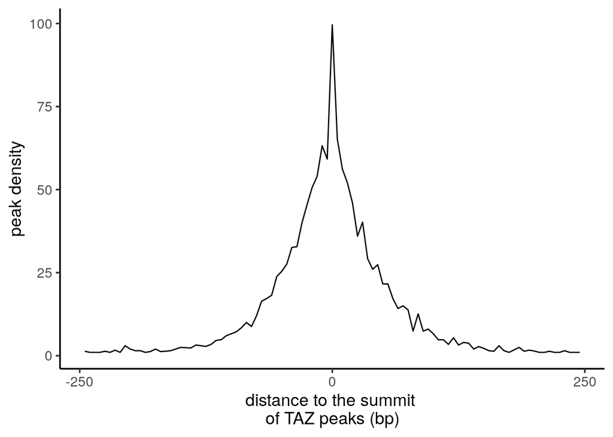

```r
df_binned %>%
  ggplot(aes(x=bin, y = n)) +
  geom_line() +
  scale_x_continuous(breaks = c(-250, 0, 250)) +
  xlab("distance to the summit \nof TAZ peaks (bp)") +
  ylab("peak density") +
  theme_classic(base_size = 14)
```